# COVID-19 Data Analysis with R - Worldwide

Yanchang Zhao

31/03/2020

### COVID-19 Data Analysis with R - Worldwide

Code written by Yanchang Zhao  
yanchang@RDataMining.com  
http://RDataMining.com  
20 March 2020

### *The code has been reconverted from PDF-document to RMarkdown- document and checked within Rstudio on a local computer by K.-P. Pleissner*

(E-Mail: pleissner@gmail.com)

## 1 Introduction

This is an analysis report of the Novel Coronavirus (COVID-19) around the world, to demonstrate data processing and visualisation with R, tidyverse and ggplot2. This report will be updated from time to time, with new data and more analysis. Please ﬁnd its latest version at http://www.rdatamining.com/docs/Coronavirus-data-analysis-world.pdf. A similar COVID-19 analysis report for China is available at http://www.rdatamining.com/docs/Coronavirus-data-analysis-china.pdf, if you are particually interested what has happened in China.

## 1.1 Data Source

The data source used for this analysis is the 2019 Novel Coronavirus COVID-19 (2019-nCoV) Data Repository1 built by the Center for Systems Science and Engineering, Johns Hopkins University.

## 1.2 R Packages

Blow is a list of R packages used for this analysis. Package magrittr is for pipe operations like %>% and %<>% and lubridate for date operations. Package tidyverse is a collection of R packages for data science, including dplyr and tidyr for data processing and ggplot2 for graphics. Package gridExtra is for arranging multiple grid-based plots on a page and kableExtra works together with kable() from knitr to build complex HTML or LaTeX tables.

```r
# clear all
rm(list = ls(all = TRUE))


library(magrittr) # pipe operations
library(lubridate) # date operations
library(tidyverse) # ggplot2, tidyr, dplyr...
library(gridExtra) # multiple grid-based plots on a page
library(ggforce) # accelerating ggplot2
library(kableExtra) # complex tables
#library(kable) # complex tables
library(leaflet) ## map
```

## 2 Loading Data

At ﬁrst, the datasets, which are three CSV ﬁles, are downloaded and saved as local ﬁles and then are loaded into R.

```r
###############  new ####################
# taken from COVID19-Daily-Dashboard.Rmd
# with new data file structure at JHU


link <- "https://github.com//CSSEGISandData/COVID-19/raw/master/csse_covid_19_data/csse_covid_19_time_series/"
csv_list <- c(
  "time_series_covid19_confirmed_global.csv",
  "time_series_covid19_deaths_global.csv",
  "time_series_covid19_recovered_global.csv"
)

for (csv in csv_list) {
  path <- paste(link, csv, sep = "")
  download_path <- paste("data_raw/", csv, sep = "")
  download.file(path, destfile = download_path)

}

## load data into R
raw.data.confirmed <- read.csv('./data_raw/time_series_covid19_confirmed_global.csv')
raw.data.deaths <- read.csv('./data_raw/time_series_covid19_deaths_global.csv')
raw.data.recovered <- read.csv('./data_raw/time_series_covid19_recovered_global.csv')

dim(raw.data.confirmed)
```

```
## [1] 264  86
```

```r
raw.data.confirmed[1:10, 1:10] %>%
#kable('latex', booktabs=T, caption='Raw Data (Confirmed, First 10 Columns only)')
kable( caption='Raw Data (Confirmed, First 10 Columns only)') %>%
kable_styling(font_size=10, latex_options = c('striped', 'hold_position', 'repeat_header'))
```

Raw Data (Confirmed, First 10 Columns only)

| Province.State | Country.Region | Lat | Long | X1.22.20 | X1.23.20 | X1.24.20 | X1.25.20 | X1.26.20 | X1.27.20 |
| --- | --- | --- | --- | --- | --- | --- | --- | --- | --- |
|  | Afghanistan | 33.0000 | 65.0000 | 0 | 0 | 0 | 0 | 0 | 0 |
|  | Albania | 41.1533 | 20.1683 | 0 | 0 | 0 | 0 | 0 | 0 |
|  | Algeria | 28.0339 | 1.6596 | 0 | 0 | 0 | 0 | 0 | 0 |
|  | Andorra | 42.5063 | 1.5218 | 0 | 0 | 0 | 0 | 0 | 0 |
|  | Angola | -11.2027 | 17.8739 | 0 | 0 | 0 | 0 | 0 | 0 |
|  | Antigua and Barbuda | 17.0608 | -61.7964 | 0 | 0 | 0 | 0 | 0 | 0 |
|  | Argentina | -38.4161 | -63.6167 | 0 | 0 | 0 | 0 | 0 | 0 |
|  | Armenia | 40.0691 | 45.0382 | 0 | 0 | 0 | 0 | 0 | 0 |
| Australian Capital Territory | Australia | -35.4735 | 149.0124 | 0 | 0 | 0 | 0 | 0 | 0 |
| New South Wales | Australia | -33.8688 | 151.2093 | 0 | 0 | 0 | 0 | 3 | 4 |

Below we check the time frame of the data.

```r
n.col <- ncol(raw.data.confirmed)
## get dates from column names
dates <- names(raw.data.confirmed)[5:n.col] %>% substr(2,8) %>% mdy()
range(dates)
```

```
## [1] "2020-01-22" "2020-04-12"
```

```r
## [1] "2020-01-22" "2020-03-26"
min.date <- min(dates)
max.date <- max(dates)
min.date.txt <- min.date %>% format('%d %b %Y')
max.date.txt <- max.date %>% format('%d %b %Y')
```

## 3 Data Preparation

# 3.1 Data Cleaning

The three datesets are converted from wide to long format and then are aggregated by country. After that, they are merged into one single dataset.

```r
## data cleaning and transformation
cleanData <- function(data) {
## remove some columns
data %<>% select(-c(Province.State, Lat, Long)) %>% rename(country=Country.Region)
## convert from wide to long format
data %<>% gather(key=date, value=count, -country)
## convert from character to date
data %<>% mutate(date = date %>% substr(2,8) %>% mdy())
## aggregate by country
data %<>% group_by(country, date) %>% summarise(count=sum(count, na.rm=T)) %>% as.data.frame()
return(data)
}

## clean the three datasets
data.confirmed <- raw.data.confirmed %>% cleanData() %>% rename(confirmed=count)
data.deaths <- raw.data.deaths %>% cleanData() %>% rename(deaths=count)
data.recovered <- raw.data.recovered %>% cleanData() %>% rename(recovered=count)

## merge above 3 datasets into one, by country and date
data <- data.confirmed %>% merge(data.deaths, all=T) %>% merge(data.recovered, all=T)
# data %<>% mutate(recovered = ifelse(is.na(recovered), lag(recovered, 1), recovered))

## countries/regions with confirmed cases, excl. cruise ships
countries <- data %>% pull(country) %>% setdiff('Cruise Ship')

## first 10 records when it first broke out in China
data %>% filter(country=='China') %>% head(10) %>%
kable( booktabs=T, caption='Raw Data (with first 10 Columns Only)',
format.args=list(big.mark=',')) %>%
kable_styling(latex_options = c('striped', 'hold_position', 'repeat_header'))
```

Raw Data (with first 10 Columns Only)

| country | date | confirmed | deaths | recovered |
| --- | --- | --- | --- | --- |
| China | 2020-01-22 | 548 | 17 | 28 |
| China | 2020-01-23 | 643 | 18 | 30 |
| China | 2020-01-24 | 920 | 26 | 36 |
| China | 2020-01-25 | 1,406 | 42 | 39 |
| China | 2020-01-26 | 2,075 | 56 | 49 |
| China | 2020-01-27 | 2,877 | 82 | 58 |
| China | 2020-01-28 | 5,509 | 131 | 101 |
| China | 2020-01-29 | 6,087 | 133 | 120 |
| China | 2020-01-30 | 8,141 | 171 | 135 |
| China | 2020-01-31 | 9,802 | 213 | 214 |

## 3.2 Worldwide Cases

The raw data provide the daily number of cases in every country. They are aggregated below to derive the daily stats of the whole world.

```r
## counts for the whole world
data.world <- data %>% group_by(date) %>%
summarise(country='World',
confirmed = sum(confirmed, na.rm=T),
deaths = sum(deaths, na.rm=T),
recovered = sum(recovered, na.rm=T))

data %<>% rbind(data.world)

## current confirmed cases
data %<>% mutate(current.confirmed = confirmed - deaths - recovered)
```

## 3.3 Daily Increases and Death Rates

After that, the daily increases of death and recovered cases and the death rates are calculated. rate.upper is caculated with the total dead and recovered cases. It is the upper bound of death rate and the reasons are 1) there were much more deaths than recovered cases when the coronavirus broke out and when it was not contained, and 2) the daily number of death will decrease and that of recovered will increase as it becomes contained and more eﬀective measures and treatments are used. rate.lower is caculated with total dead and conﬁrmed cases. It is a lower bound of death rate, because there are and will be new deaths from the current conﬁrmed cases. The ﬁnal death rate is expected to be in between of the above two rates. rate.daily is caculated with the daily dead and recovered cases and therefore is more volatile than the above two. However, it can give us a clue of the current situlation: whether it is very serious or is getting better.

```r
## sort by country and date
data %<>% arrange(country, date)

## daily increases of deaths and recovered cases
## set NA to the increases on day1
n <- nrow(data)
day1 <- min(data$date)
data %<>% mutate(new.confirmed = ifelse(date == day1, NA, confirmed - lag(confirmed, n=1)),
new.deaths = ifelse(date == day1, NA, deaths - lag(deaths, n=1)),
new.recovered = ifelse(date == day1, NA, recovered - lag(recovered, n=1)))

## change negative number of new cases to zero
data %<>% mutate(new.confirmed = ifelse(new.confirmed < 0, 0, new.confirmed),
new.deaths = ifelse(new.deaths < 0, 0, new.deaths),
new.recovered = ifelse(new.recovered < 0, 0, new.recovered))

## death rate based on total deaths and recovered cases
data %<>% mutate(rate.upper = (100 * deaths / (deaths + recovered)) %>% round(1))
## lower bound: death rate based on total confirmed cases
data %<>% mutate(rate.lower = (100 * deaths / confirmed) %>% round(1))
## death rate based on the number of death/recovered on every single day
data %<>% mutate(rate.daily = (100 * new.deaths / (new.deaths + new.recovered)) %>% round(1))

## convert from wide to long format, for drawing area plots
data.long <- data %>%
select(c(country, date, confirmed, current.confirmed, recovered, deaths)) %>%
gather(key=type, value=count, -c(country, date))
## set factor levels to show them in a desirable order
data.long %<>% mutate(type=recode_factor(type, confirmed='Total Confirmed',
current.confirmed='Current Confirmed',
recovered='Recovered',
deaths='Deaths'))

## convert from wide to long format, for drawing area plots
rates.long <- data %>%
# filter(country %in% top.countries) %>%
select(c(country, date, rate.upper, rate.lower, rate.daily)) %>%
# mutate(country=factor(country, levels=top.countries)) %>%
gather(key=type, value=count, -c(country, date))
# set factor levels to show them in a desirable order

rates.long %<>% mutate(type=recode_factor(type, rate.daily='Daily',
rate.lower='Lower bound',
rate.upper='Upper bound'))
```

## 4 Worldwide Cases

After tidying up the data, we visualise it with various charts.

# 4.1 World Map

Below is a world map of vconﬁrmed cases. An interactive map can be created if running the code in R or RStudio, or knitting it into a HTML ﬁle.

```r
## select last column, which is the number of latest confirmed cases
## select last column, which is the number of latest confirmed cases
x <- raw.data.confirmed
x$confirmed <- x[, ncol(x)]
x %<>% select(c(Country.Region, Province.State, Lat, Long, confirmed)) %>%
mutate(txt=paste0(Country.Region, ' - ', Province.State, ': ', confirmed))

m <- leaflet(width=1200, height=800) %>% addTiles()
# circle marker (units in pixels)
m %<>% addCircleMarkers(x$Long, x$Lat,
radius=2+log2(x$confirmed), stroke=F,
color='red', fillOpacity=0.3,
popup=x$txt)

# world
m
```

[interactive chart not shown]

Views of some specific countries or regions can be produced with the script below.

## China

```r
m %>% setView(95, 35, zoom=4)
```

[interactive chart not shown]

## Australia and New Zealand

```r
m %>% setView(135, -27, zoom=4)
```

[interactive chart not shown]

## US and Canada

```r
m %>% setView(-105, 40, zoom=4)
```

[interactive chart not shown]

## Europe

```r
m %>% setView(10, 50, zoom=4)
```

[interactive chart not shown]

## 4.2 Number of Cases

In the rest of this section, we will focuse on the cases worldwide. Similar analysis for a single country can be done by ﬁlter the data with the corresponding country name.

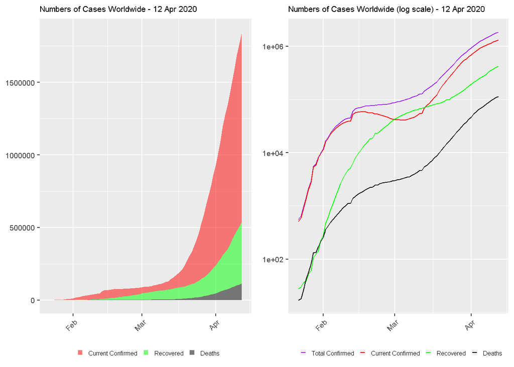

```r
 # data %<>% filter(country=='China')
# data %<>% filter(country=='Australia')
world.long <- data.long %>% filter(country == 'World')

## cases - area plot
plot1 <- world.long %>% filter(type != 'Total Confirmed') %>%
ggplot(aes(x=date, y=count)) +
geom_area(aes(fill=type), alpha=0.5) +
labs(title=paste0('Numbers of Cases Worldwide - ', max.date.txt)) +
scale_fill_manual(values=c('red', 'green', 'black')) +
theme(legend.title=element_blank(), legend.position='bottom',
plot.title = element_text(size=8),
axis.title.x=element_blank(),
axis.title.y=element_blank(),
legend.key.size=unit(0.2, 'cm'),
legend.text=element_text(size=6),
axis.text=element_text(size=7),
axis.text.x=element_text(angle=45, hjust=1))

plot2 <- world.long %>%
ggplot(aes(x=date, y=count)) +
geom_line(aes(color=type)) +
labs(title=paste0('Numbers of Cases Worldwide (log scale) - ', max.date.txt)) +
scale_color_manual(values=c('purple', 'red', 'green', 'black')) +
theme(legend.title=element_blank(), legend.position='bottom',
plot.title = element_text(size=8),
axis.title.x=element_blank(),
axis.title.y=element_blank(),
legend.key.size=unit(0.2, 'cm'),
legend.text=element_text(size=6),
axis.text=element_text(size=7),
axis.text.x=element_text(angle=45, hjust=1)) +
scale_y_continuous(trans='log10')

grid.arrange(plot1, plot2, ncol=2)
```

## 4.3 Current Conﬁrmed Cases

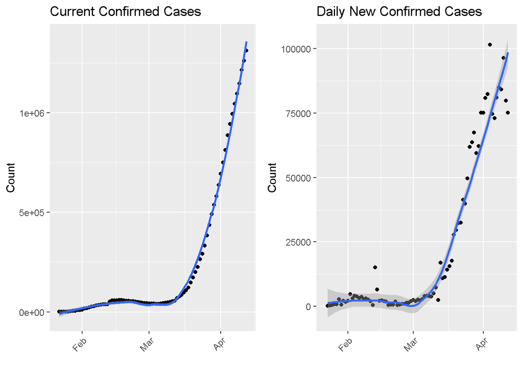

```r
data.world <- data %>% filter(country=='World')
n <- nrow(data.world)
## current confirmed and daily new confirmed
plot1 <- ggplot(data.world, aes(x=date, y=current.confirmed)) +
geom_point() + geom_smooth() +
xlab('') + ylab('Count') + labs(title='Current Confirmed Cases') +
theme(axis.text.x=element_text(angle=45, hjust=1))
plot2 <- ggplot(data.world, aes(x=date, y=new.confirmed)) +
geom_point() + geom_smooth() +
xlab('') + ylab('Count') + labs(title='Daily New Confirmed Cases') +
theme(axis.text.x=element_text(angle=45, hjust=1))
## show two plots side by side
grid.arrange(plot1, plot2, ncol=2)
```

Figure 3 shows the numbers of current (see left chart) and new (see right chart) conﬁrmed cases. The blue lines are smoothed conditional means and the grey band around them show the 95% conﬁdence interval.

## 4.4 Deaths and Recovered Cases

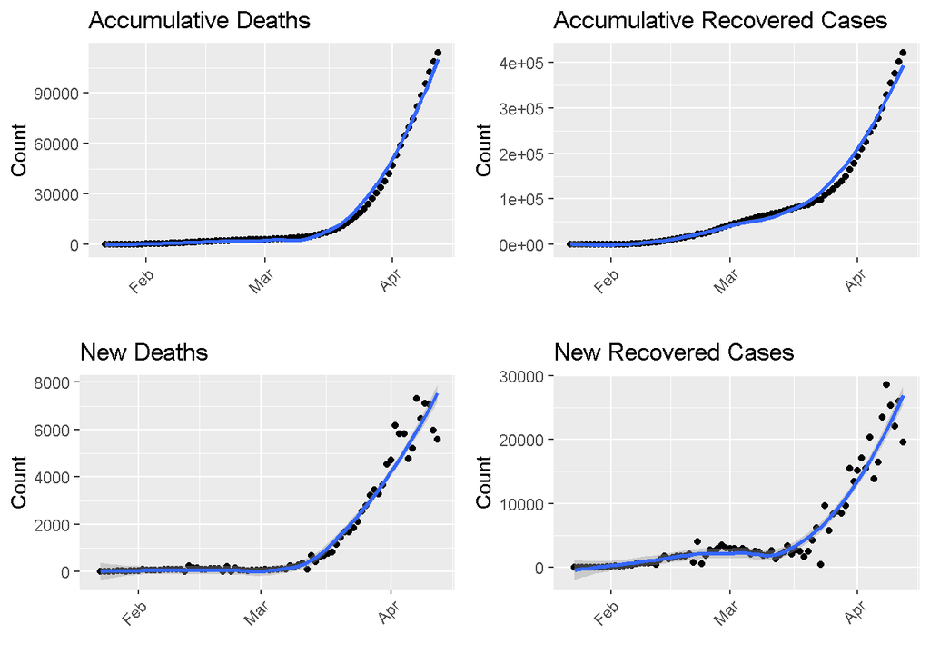

```r
## a scatter plot with a smoothed line and vertical x-axis labels
plot1 <- ggplot(data.world, aes(x=date, y=deaths)) +
geom_point() + geom_smooth() +
xlab('') + ylab('Count') + labs(title='Accumulative Deaths') +
theme(axis.text.x=element_text(angle=45, hjust=1))
plot2 <- ggplot(data.world, aes(x=date, y=recovered)) +
geom_point() + geom_smooth() +
xlab('') + ylab('Count') + labs(title='Accumulative Recovered Cases') +
theme(axis.text.x=element_text(angle=45, hjust=1))
plot3 <- ggplot(data.world, aes(x=date, y=new.deaths)) +
geom_point() + geom_smooth() +
xlab('') + ylab('Count') + labs(title='New Deaths') +
theme(axis.text.x=element_text(angle=45, hjust=1))
plot4 <- ggplot(data.world, aes(x=date, y=new.recovered)) +
geom_point() + geom_smooth() +
xlab('') + ylab('Count') + labs(title='New Recovered Cases') +
theme(axis.text.x=element_text(angle=45, hjust=1))
## show four plots together, with 2 plots in each row
grid.arrange(plot1, plot2, plot3, plot4, nrow=2)
```

## 4.5 Death Rates

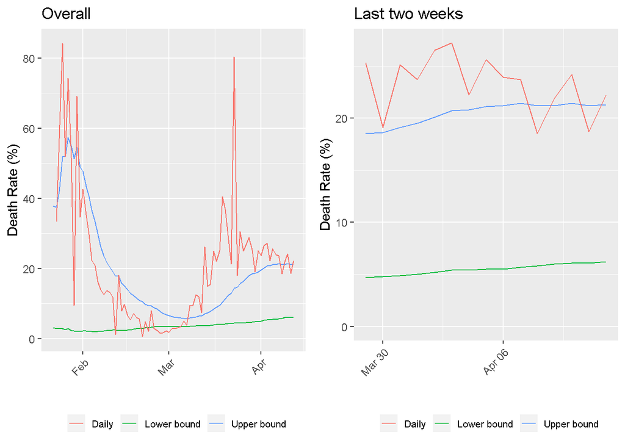

```r
## three death rates
plot1 <- ggplot(data.world, aes(x=date)) +
  geom_line(aes(y=rate.upper, colour='Upper bound')) +
geom_line(aes(y=rate.lower, colour='Lower bound')) +
geom_line(aes(y=rate.daily, colour='Daily')) +
xlab('') + ylab('Death Rate (%)') + labs(title='Overall') +
theme(legend.position='bottom', legend.title=element_blank(),
legend.text=element_text(size=8),
legend.key.size=unit(0.5, 'cm'),
axis.text.x=element_text(angle=45, hjust=1))
## focusing on last 2 weeks
y.max <- data.world[n-(14:0), ] %>% select(rate.upper, rate.lower, rate.daily) %>% max()
plot2 <- ggplot(data.world[n-(14:0),], aes(x=date)) +
geom_line(aes(y=rate.upper, colour='Upper bound')) +
geom_line(aes(y=rate.lower, colour='Lower bound')) +
geom_line(aes(y=rate.daily, colour='Daily')) +
xlab('') + ylab('Death Rate (%)') + labs(title='Last two weeks') +
theme(legend.position='bottom', legend.title=element_blank(),
legend.text=element_text(size=8),
legend.key.size=unit(0.5, 'cm'),
axis.text.x=element_text(angle=45, hjust=1)) +
ylim(c(0, y.max))
grid.arrange(plot1, plot2, ncol=2)
```

## 5 Top Twenty Countries

Next, we will have a look at the top 20 countries in total conﬁrmed cases.

```r
## ranking by confirmed cases
data.latest.all <- data %>% filter(date == max(date)) %>%
select(country, date,
confirmed, new.confirmed, current.confirmed,
recovered, deaths, new.deaths, death.rate=rate.lower) %>%
mutate(ranking = dense_rank(desc(confirmed)))

k <- 20
## top 20 countries: 21 incl. 'World'
top.countries <- data.latest.all %>% filter(ranking <= k + 1) %>%
arrange(ranking) %>% pull(country) %>% as.character()
top.countries %>% setdiff('World') %>% print()
```

```
##  [1] "US"             "Spain"          "Italy"          "France"
##  [5] "Germany"        "United Kingdom" "China"          "Iran"
##  [9] "Turkey"         "Belgium"        "Netherlands"    "Switzerland"
## [13] "Canada"         "Brazil"         "Portugal"       "Russia"
## [17] "Austria"        "Israel"         "Korea, South"   "Sweden"
```

```r
## add 'Others'
top.countries %<>% c('Others')
## put all others in a single group of 'Others'
data.latest <- data.latest.all %>% filter(!is.na(country)) %>%
mutate(country=ifelse(ranking <= k + 1, as.character(country), 'Others')) %>%
mutate(country=country %>% factor(levels=c(top.countries)))
data.latest %<>% group_by(country) %>%
summarise(confirmed=sum(confirmed), new.confirmed=sum(new.confirmed),
current.confirmed=sum(current.confirmed),
recovered=sum(recovered), deaths=sum(deaths), new.deaths=sum(new.deaths)) %>%
mutate(death.rate=(100 * deaths/confirmed) %>% round(1))
data.latest %<>% select(c(country, confirmed, deaths, death.rate,
new.confirmed, new.deaths, current.confirmed))
data.latest %>% mutate(death.rate=death.rate %>% format(nsmall=1) %>% paste0('%')) %>%
#kable('latex', booktabs=T, row.names=T, #align=c('l', rep('r', 6)),
kable( booktabs=T, row.names=T, align=c('l', rep('r', 6)),
caption=paste0('Cases in Top 20 Countries - ', max.date.txt,
'. See a complete list of all infected countries at the end of this report.'),
format.args=list(big.mark=',')) %>%
kable_styling(font_size=10, latex_options=c('striped', 'hold_position', 'repeat_header'))
```

Cases in Top 20 Countries - 12 Apr 2020. See a complete list of all infected countries at the end of this report.

|  | country | confirmed | deaths | death.rate | new.confirmed | new.deaths | current.confirmed |
| --- | --- | --- | --- | --- | --- | --- | --- |
| 1 | World | 1,846,679 | 114,091 | 6.2% | 75,165 | 5,588 | 1,310,866 |
| 2 | US | 555,313 | 22,020 | 4.0% | 28,917 | 1,557 | 500,305 |
| 3 | Spain | 166,831 | 17,209 | 10.3% | 3,804 | 603 | 87,231 |
| 4 | Italy | 156,363 | 19,899 | 12.7% | 4,092 | 431 | 102,253 |
| 5 | France | 133,670 | 14,412 | 10.8% | 2,943 | 561 | 91,789 |
| 6 | Germany | 127,854 | 3,022 | 2.4% | 2,946 | 286 | 64,532 |
| 7 | United Kingdom | 85,206 | 10,629 | 12.5% | 5,332 | 737 | 73,951 |
| 8 | China | 83,134 | 3,343 | 4.0% | 120 | 0 | 1,835 |
| 9 | Iran | 71,686 | 4,474 | 6.2% | 1,657 | 117 | 23,318 |
| 10 | Turkey | 56,956 | 1,198 | 2.1% | 4,789 | 97 | 52,312 |
| 11 | Belgium | 29,647 | 3,600 | 12.1% | 1,629 | 254 | 19,584 |
| 12 | Netherlands | 25,746 | 2,747 | 10.7% | 1,175 | 94 | 22,704 |
| 13 | Switzerland | 25,415 | 1,106 | 4.4% | 308 | 70 | 11,609 |
| 14 | Canada | 24,298 | 714 | 2.9% | 982 | 60 | 16,461 |
| 15 | Brazil | 22,192 | 1,223 | 5.5% | 1,465 | 99 | 20,796 |
| 16 | Portugal | 16,585 | 504 | 3.0% | 598 | 34 | 15,804 |
| 17 | Russia | 15,770 | 130 | 0.8% | 2,186 | 24 | 14,349 |
| 18 | Austria | 13,945 | 350 | 2.5% | 139 | 13 | 6,608 |
| 19 | Israel | 11,145 | 103 | 0.9% | 402 | 2 | 9,415 |
| 20 | Korea, South | 10,512 | 214 | 2.0% | 32 | 3 | 2,930 |
| 21 | Sweden | 10,483 | 899 | 8.6% | 332 | 12 | 9,203 |
| 22 | Others | 203,928 | 6,295 | 3.1% | 11,331 | 534 | 163,877 |

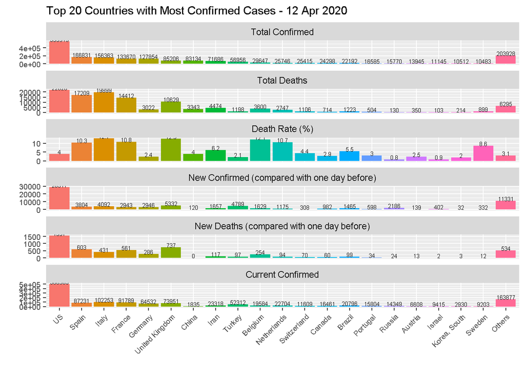

```r
## convert from wide to long format, for drawing area plots
data.latest.long <- data.latest %>% filter(country!='World') %>%
gather(key=type, value=count, -country)
## set factor levels to show them with proper text and in a desirable order
data.latest.long %<>% mutate(type=recode_factor(type,
confirmed='Total Confirmed',
deaths='Total Deaths',
death.rate='Death Rate (%)',
new.confirmed='New Confirmed (compared with one day before)',
new.deaths='New Deaths (compared with one day before)',
current.confirmed='Current Confirmed'))
## bar chart
data.latest.long %>% ggplot(aes(x=country, y=count, fill=country, group=country)) +
geom_bar(stat='identity') +
geom_text(aes(label=count, y=count), size=2, vjust=0) +
xlab('') + ylab('') +
labs(title=paste0('Top 20 Countries with Most Confirmed Cases - ', max.date.txt)) +
scale_fill_discrete(name='Country', labels=aes(count)) +
theme(legend.title=element_blank(),
legend.position='none',
plot.title=element_text(size=11),
axis.text=element_text(size=7),
axis.text.x=element_text(angle=45, hjust=1)) +
facet_wrap(~type, ncol=1, scales='free_y')
```

## 5.1 Conﬁrmed vs Deaths

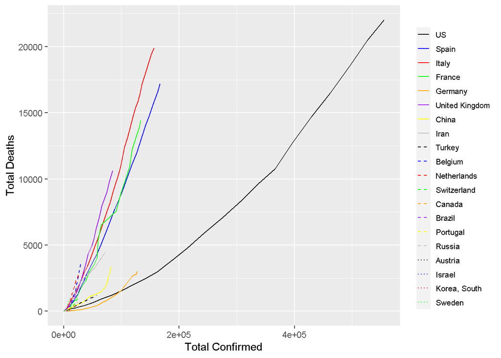

```r
# linetypes <- rep(c("dotted", "dashed", "solid"), each=8)
# colors <- rep(c('grey', 'yellow', 'purple', 'orange', 'green', 'red', 'blue', 'black'), 3)
linetypes <- rep(c("solid", "dashed", "dotted"), each=8)
colors <- rep(c('black', 'blue', 'red', 'green', 'orange', 'purple', 'yellow', 'grey'), 3)
df <- data %>% filter(country %in% setdiff(top.countries, c('World', 'Others'))) %>%
mutate(country=country %>% factor(levels=c(top.countries)))
p <- df %>% ggplot(aes(x=confirmed, y=deaths, group=country)) +
geom_line(aes(color=country, linetype=country)) +
xlab('Total Confirmed') + ylab('Total Deaths') +
scale_linetype_manual(values=linetypes) +
scale_color_manual(values=colors) +
theme(legend.title=element_blank(),
legend.text=element_text(size=8),
legend.key.size=unit(0.5, 'cm'))
p
```

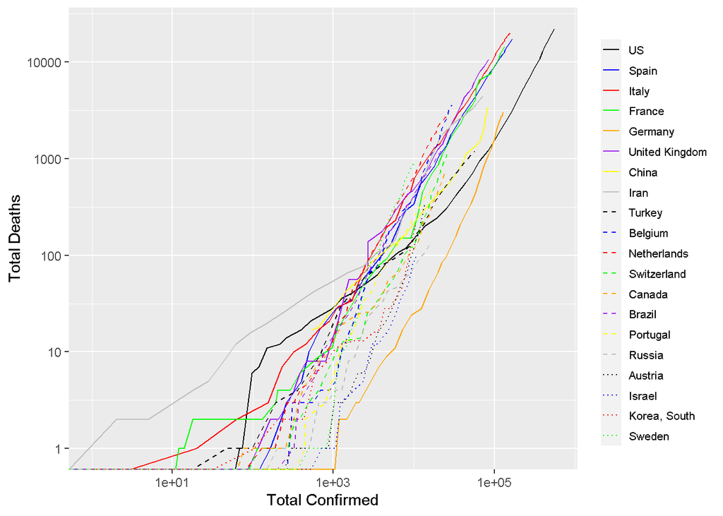

```r
p + scale_x_log10() + scale_y_log10()
```

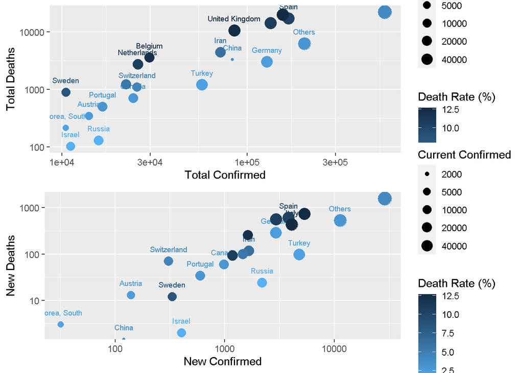

```r
df <- data.latest %>% filter(country %in% setdiff(top.countries, 'World'))

plot1 <- df %>% ggplot(aes(x=confirmed, y=deaths, col=death.rate, size=current.confirmed)) +
scale_size(name='Current Confirmed', trans='log2', breaks=c(1e3, 2e3, 5e3, 1e4, 2e4, 4e4)) +
geom_text(aes(label=country), size=2.5, check_overlap=T, vjust=-1.6) +
geom_point() +
xlab('Total Confirmed') + ylab('Total Deaths') +
labs(col="Death Rate (%)") +
scale_color_gradient(low='#56B1F7', high='#132B43') +
scale_x_log10() + scale_y_log10()

plot2 <- df %>% ggplot(aes(x=new.confirmed, y=new.deaths, col=death.rate, size=current.confirmed)) +
scale_size(name='Current Confirmed', trans='log2', breaks=c(1e3, 2e3, 5e3, 1e4, 2e4, 4e4)) +
geom_text(aes(label=country), size=2.5, check_overlap=T, vjust=-1.6) +
geom_point() +
xlab('New Confirmed') + ylab('New Deaths') +
labs(col="Death Rate (%)") +
scale_color_gradient(low='#56B1F7', high='#132B43') +
scale_x_log10() + scale_y_log10()

grid.arrange(plot1, plot2, ncol=1)
```

## 5.2 Comparison across Countries

The area plots blow show the numbers of dead, recovered, total and current conﬁmed cases. Note that, in the area plot, the total number of total conﬁrmed cases is represented by the total areas of current conﬁrmed, recovered and dead.

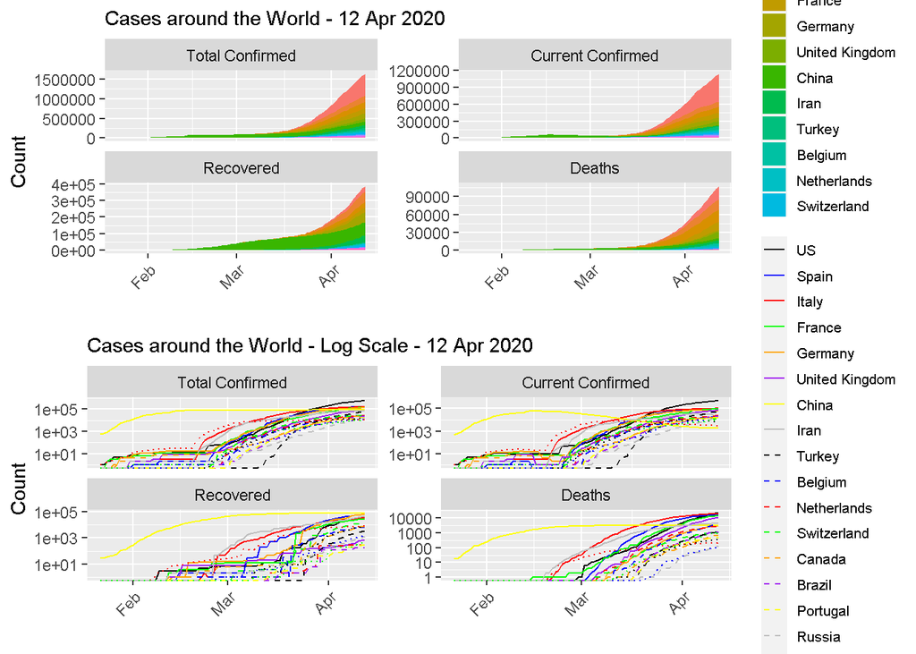

```r
## plot: cases by type
df <- data.long %>% filter(country %in% top.countries) %<>%
mutate(country=country %>% factor(levels=c(top.countries)))

p <- df %>% filter(country != 'World') %>%
ggplot(aes(x=date, y=count)) + xlab('') + ylab('Count') +
theme(legend.title=element_blank(),
legend.text=element_text(size=8),
legend.key.size=unit(0.5, 'cm'),
plot.title=element_text(size=11),
axis.text.x=element_text(angle=45, hjust=1)) +
facet_wrap(~type, ncol=2, scales='free_y')

## area plot
plot1 <- p + geom_area(aes(fill=country)) +
labs(title=paste0('Cases around the World - ', max.date.txt))

## line plot and in log scale
# linetypes <- rep(c("solid", "dashed", "dotted"), each=8)
# colors <- rep(c('black', 'blue', 'red', 'green', 'orange', 'purple', 'yellow', 'grey'), 3)
plot2 <- p + geom_line(aes(color=country, linetype=country)) +
scale_linetype_manual(values=linetypes) +
scale_color_manual(values=colors) +
labs(title=paste0('Cases around the World - Log Scale - ', max.date.txt)) +
scale_y_continuous(trans='log10')

grid.arrange(plot1, plot2, ncol=1)
```

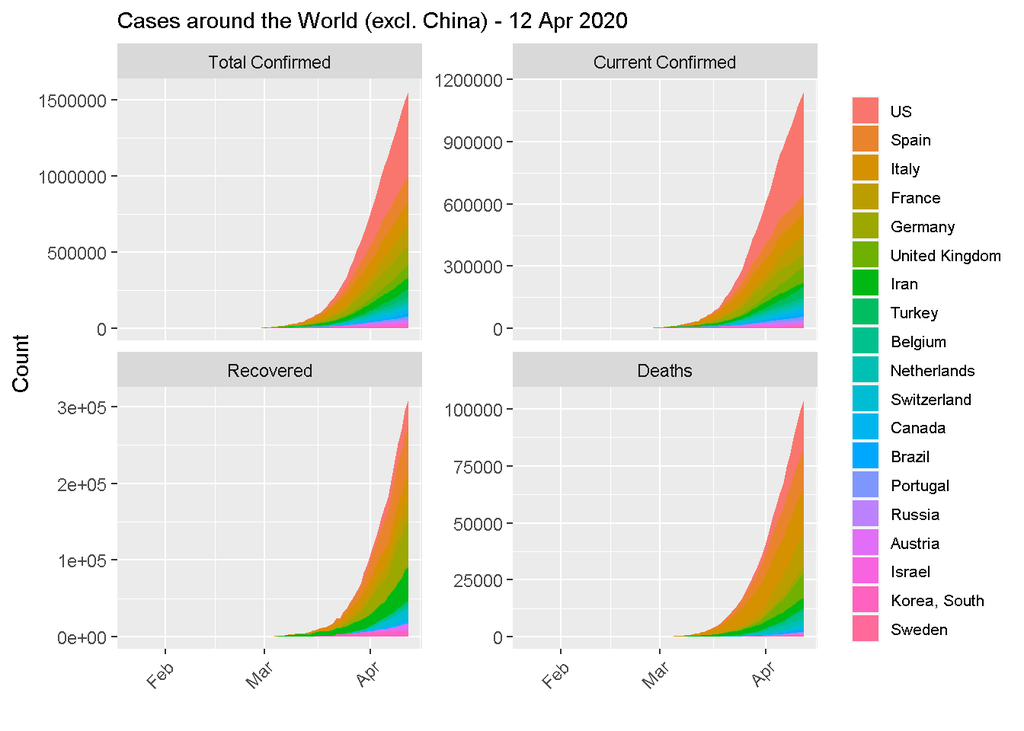

```r
## plot: excluding China
p <- df %>% filter(!(country %in% c('World', 'China'))) %>%
 ggplot(aes(x=date, y=count)) + xlab('') + ylab('Count') +
theme(legend.title=element_blank(),
legend.text=element_text(size=8),
legend.key.size=unit(0.5, 'cm'),
plot.title=element_text(size=11),
axis.text.x=element_text(angle=45, hjust=1)) +
facet_wrap(~type, ncol=2, scales='free_y')
p + geom_area(aes(fill=country)) +
labs(title=paste0('Cases around the World (excl. China) - ', max.date.txt))
```

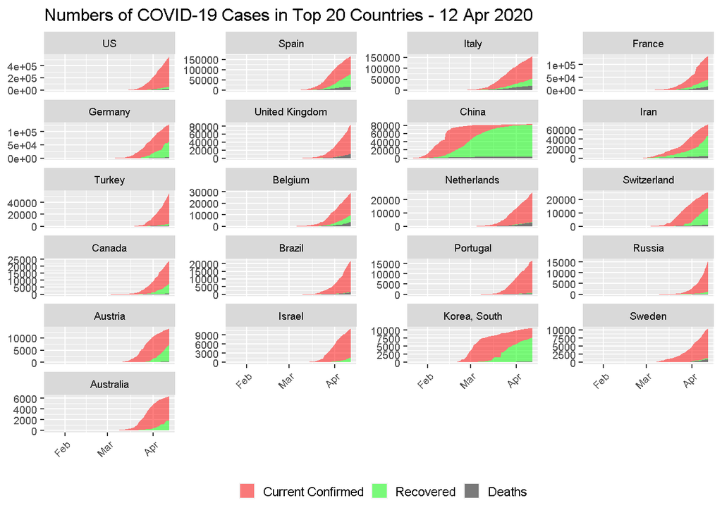

```r
## if Australia in not in top 20, add it in and remove 'Others'
if(!('Australia' %in% top.countries)) {
top.countries %<>% setdiff('Others') %>% c('Australia')
df <- data.long %>% filter(country %in% top.countries) %<>%
mutate(country=country %>% factor(levels=c(top.countries)))
}

## cases by country - area plot
df %>% filter(country != 'World' & type != 'Total Confirmed') %>%
ggplot(aes(x=date, y=count, fill=type)) +
geom_area(alpha=0.5) +
# xlab('') + ylab('') +
labs(title=paste0('Numbers of COVID-19 Cases in Top 20 Countries - ',
max.date.txt)) +
scale_fill_manual(values=c('red', 'green', 'black')) +
theme(legend.title=element_blank(), legend.position='bottom',
      plot.title = element_text(size=12),
axis.title.x=element_blank(),
axis.title.y=element_blank(),
legend.key.size=unit(0.4, 'cm'),
# legend.text=element_text(size=7),
strip.text.x=element_text(size=7),
axis.text=element_text(size=7),
axis.text.x=element_text(angle=45, hjust=1)) +
facet_wrap(~country, ncol=4, scales='free_y')
```

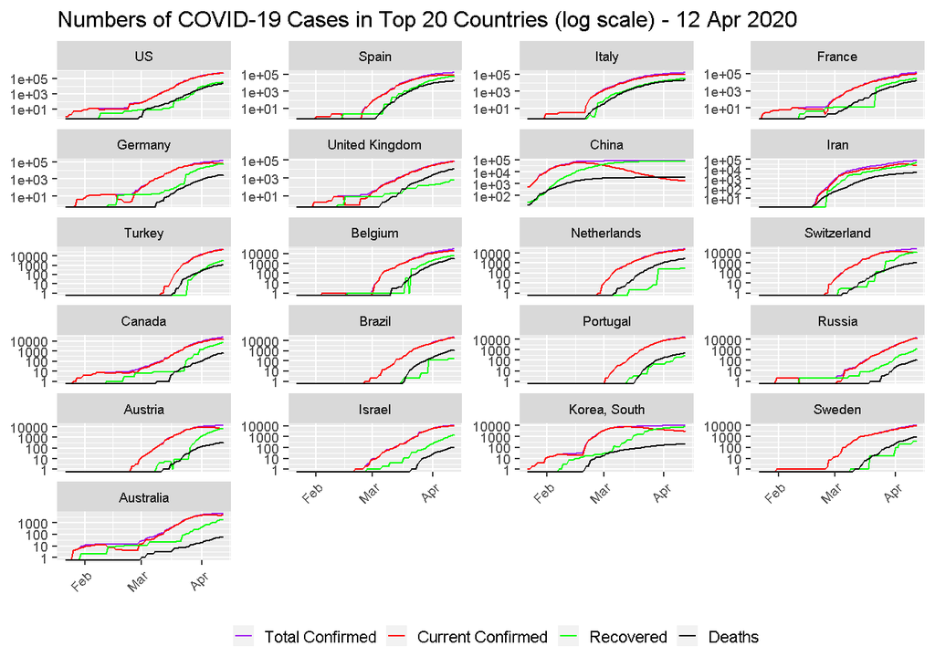

```r
## cases by country - line plot - log scale
p <- df %>% filter(country != 'World') %>%
ggplot(aes(x=date, y=count, color=type)) +
geom_line() +
labs(title=paste0('Numbers of COVID-19 Cases in Top 20 Countries (log scale) - ',
max.date.txt)) +
scale_color_manual(values=c('purple', 'red', 'green', 'black')) +
theme(legend.title=element_blank(), legend.position='bottom',
plot.title = element_text(size=12),
axis.title.x=element_blank(),
axis.title.y=element_blank(),
legend.key.size=unit(0.4, 'cm'),
# legend.text=element_text(size=7),
strip.text.x=element_text(size=7),
axis.text=element_text(size=7),
axis.text.x=element_text(angle=45, hjust=1)) +
scale_y_continuous(trans='log10')
p + facet_wrap(~country, ncol=4, scales='free_y')
```

```r
## plot over multiple pages
# p + facet_wrap_paginate(~country, nrow=4, ncol=3, page=1, scales='free_y')
# p + facet_wrap_paginate(~country, nrow=4, ncol=3, page=2, scales='free_y')
```

Figures 10 and 11 show that the coronavirus seems to be under control in China, with an increase of recovered cases (in green) every day and a shrinking of the current confrimed cases (in red). However, in the rest of the world (i.e., outside of China), the conﬁrmed cases are surging up in many other countries, which suggests that the virus has broken out there.

## 5.3 Death Rates

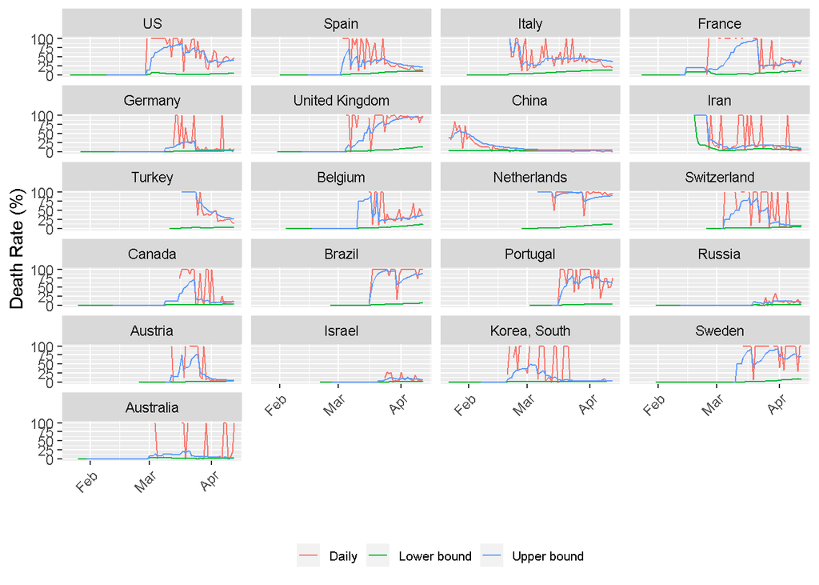

```r
## three death rates
rate.max <- rates.long$count %>% max(na.rm=T)
df <- rates.long %>% filter(country %in% setdiff(top.countries, 'World')) %>%
mutate(country=factor(country, levels=top.countries))
df %>% ggplot(aes(x=date, y=count, color=type)) +
geom_line() +
xlab('') + ylab('Death Rate (%)') +
theme(legend.position='bottom', legend.title=element_blank(),
legend.text=element_text(size=8),
legend.key.size=unit(0.5, 'cm'),
axis.text.x=element_text(angle=45, hjust=1)) +
ylim(c(0, 100)) +
facet_wrap(~country, ncol=4)
```

## 5.4 Countries with Highest Death Rates

Below are a list of top 20 countries of high death rates and with 100+ conﬁrmed cases each.

```r
## sort the latest data by death rate, and if tie, by confirmed
df <- data %>% filter(date == max(date) & country != 'World' & confirmed >= 100) %>%
select(country, confirmed, new.confirmed, current.confirmed,
recovered, deaths, new.deaths, death.rate=rate.lower) %>%
arrange(desc(death.rate, confirmed))

df %>% head(20) %>%
mutate(death.rate=death.rate %>% format(nsmall=1) %>% paste0('%')) %>%
kable( booktabs=T, row.names=T, align=c('l', rep('r', 7)),
caption=paste0('Top 20 Countries with Highest Death Rates - ', max.date.txt),
format.args=list(big.mark=',')) %>%
kable_styling(font_size=10, latex_options=c('striped', 'hold_position', 'repeat_header'))
```

Top 20 Countries with Highest Death Rates - 12 Apr 2020

|  | country | confirmed | new.confirmed | current.confirmed | recovered | deaths | new.deaths | death.rate |
| --- | --- | --- | --- | --- | --- | --- | --- | --- |
| 1 | Algeria | 1,914 | 89 | 1,030 | 591 | 293 | 18 | 15.3% |
| 2 | Italy | 156,363 | 4,092 | 102,253 | 34,211 | 19,899 | 431 | 12.7% |
| 3 | United Kingdom | 85,206 | 5,332 | 73,951 | 626 | 10,629 | 737 | 12.5% |
| 4 | Belgium | 29,647 | 1,629 | 19,584 | 6,463 | 3,600 | 254 | 12.1% |
| 5 | France | 133,670 | 2,943 | 91,789 | 27,469 | 14,412 | 561 | 10.8% |
| 6 | Netherlands | 25,746 | 1,175 | 22,704 | 295 | 2,747 | 94 | 10.7% |
| 7 | Spain | 166,831 | 3,804 | 87,231 | 62,391 | 17,209 | 603 | 10.3% |
| 8 | San Marino | 356 | 0 | 268 | 53 | 35 | 0 | 9.8% |
| 9 | Indonesia | 4,241 | 399 | 3,509 | 359 | 373 | 46 | 8.8% |
| 10 | Mali | 105 | 18 | 74 | 22 | 9 | 2 | 8.6% |
| 11 | Sweden | 10,483 | 332 | 9,203 | 381 | 899 | 12 | 8.6% |
| 12 | Congo (Kinshasa) | 234 | 11 | 198 | 16 | 20 | 0 | 8.5% |
| 13 | Bolivia | 300 | 25 | 274 | 2 | 24 | 4 | 8.0% |
| 14 | Egypt | 2,065 | 126 | 1,317 | 589 | 159 | 13 | 7.7% |
| 15 | Morocco | 1,661 | 116 | 1,366 | 177 | 118 | 7 | 7.1% |
| 16 | Trinidad and Tobago | 113 | 1 | 89 | 16 | 8 | 0 | 7.1% |
| 17 | Hungary | 1,410 | 100 | 1,193 | 118 | 99 | 14 | 7.0% |
| 18 | Mexico | 4,219 | 375 | 2,174 | 1,772 | 273 | 40 | 6.5% |
| 19 | Honduras | 393 | 1 | 361 | 7 | 25 | 1 | 6.4% |
| 20 | Philippines | 4,648 | 220 | 4,154 | 197 | 297 | 50 | 6.4% |

## Appendix A. Processed Data

Blow is the processed data for this analysis.

```r
## sort by date descendingly and re-order columns
data.world %<>% arrange(desc(date)) %>%
select(c(date, confirmed, deaths, recovered, current.confirmed,
         new.confirmed, new.deaths, new.recovered, rate.lower, rate.upper, rate.daily))
## output as a table
data.world %>% kable( booktabs=T, longtable=T, caption='Cases in the Whole World',
format.args=list(big.mark=',')) %>%
kable_styling(font_size=10, latex_options=c('striped', 'hold_position', 'repeat_header'))
```

Cases in the Whole World

| date | confirmed | deaths | recovered | current.confirmed | new.confirmed | new.deaths | new.recovered | rate.lower | rate.upper | rate.daily |
| --- | --- | --- | --- | --- | --- | --- | --- | --- | --- | --- |
| 2020-04-12 | 1,846,679 | 114,091 | 421,722 | 1,310,866 | 75,165 | 5,588 | 19,612 | 6.2 | 21.3 | 22.2 |
| 2020-04-11 | 1,771,514 | 108,503 | 402,110 | 1,260,901 | 79,795 | 5,978 | 26,014 | 6.1 | 21.2 | 18.7 |
| 2020-04-10 | 1,691,719 | 102,525 | 376,096 | 1,213,098 | 96,369 | 7,070 | 22,121 | 6.1 | 21.4 | 24.2 |
| 2020-04-09 | 1,595,350 | 95,455 | 353,975 | 1,145,920 | 84,246 | 7,117 | 25,314 | 6.0 | 21.2 | 21.9 |
| 2020-04-08 | 1,511,104 | 88,338 | 328,661 | 1,094,105 | 85,008 | 6,473 | 28,607 | 5.8 | 21.2 | 18.5 |
| 2020-04-07 | 1,426,096 | 81,865 | 300,054 | 1,044,177 | 80,995 | 7,300 | 23,539 | 5.7 | 21.4 | 23.7 |
| 2020-04-06 | 1,345,101 | 74,565 | 276,515 | 994,021 | 72,986 | 5,191 | 16,503 | 5.5 | 21.2 | 23.9 |
| 2020-04-05 | 1,272,115 | 69,374 | 260,012 | 942,729 | 74,707 | 4,768 | 13,860 | 5.5 | 21.1 | 25.6 |
| 2020-04-04 | 1,197,408 | 64,606 | 246,152 | 886,650 | 101,491 | 5,819 | 20,356 | 5.4 | 20.8 | 22.2 |
| 2020-04-03 | 1,095,917 | 58,787 | 225,796 | 811,334 | 82,451 | 5,804 | 15,533 | 5.4 | 20.7 | 27.2 |
| 2020-04-02 | 1,013,466 | 52,983 | 210,263 | 750,220 | 80,861 | 6,174 | 17,086 | 5.2 | 20.1 | 26.5 |
| 2020-04-01 | 932,605 | 46,809 | 193,177 | 692,619 | 75,118 | 4,702 | 15,143 | 5.0 | 19.5 | 23.7 |
| 2020-03-31 | 857,487 | 42,107 | 178,034 | 637,346 | 75,098 | 4,525 | 13,468 | 4.9 | 19.1 | 25.1 |
| 2020-03-30 | 782,389 | 37,582 | 164,566 | 580,241 | 62,249 | 3,657 | 15,484 | 4.8 | 18.6 | 19.1 |
| 2020-03-29 | 720,140 | 33,925 | 149,082 | 537,133 | 59,447 | 3,273 | 9,667 | 4.7 | 18.5 | 25.3 |
| 2020-03-28 | 660,693 | 30,652 | 139,415 | 490,626 | 67,402 | 3,454 | 8,500 | 4.6 | 18.0 | 28.9 |
| 2020-03-27 | 593,291 | 27,198 | 130,915 | 435,178 | 63,700 | 3,228 | 8,765 | 4.6 | 17.2 | 26.9 |
| 2020-03-26 | 529,591 | 23,970 | 122,150 | 383,471 | 61,938 | 2,789 | 8,363 | 4.5 | 16.4 | 25.0 |
| 2020-03-25 | 467,653 | 21,181 | 113,787 | 332,685 | 49,608 | 2,556 | 5,787 | 4.5 | 15.7 | 30.6 |
| 2020-03-24 | 418,045 | 18,625 | 108,000 | 291,420 | 39,810 | 2,120 | 9,649 | 4.5 | 14.7 | 18.0 |
| 2020-03-23 | 378,235 | 16,505 | 98,351 | 263,379 | 41,282 | 1,854 | 452 | 4.4 | 14.4 | 80.4 |
| 2020-03-22 | 336,953 | 14,651 | 97,899 | 224,403 | 32,446 | 1,678 | 6,207 | 4.3 | 13.0 | 21.3 |
| 2020-03-21 | 304,507 | 12,973 | 91,692 | 199,842 | 32,299 | 1,674 | 4,272 | 4.3 | 12.4 | 28.2 |
| 2020-03-20 | 272,208 | 11,299 | 87,420 | 173,489 | 29,638 | 1,432 | 2,445 | 4.2 | 11.4 | 36.9 |
| 2020-03-19 | 242,570 | 9,867 | 84,975 | 147,728 | 27,749 | 1,134 | 1,663 | 4.1 | 10.4 | 40.5 |
| 2020-03-18 | 214,821 | 8,733 | 83,312 | 122,776 | 17,719 | 828 | 2,472 | 4.1 | 9.5 | 25.1 |
| 2020-03-17 | 197,102 | 7,905 | 80,840 | 108,357 | 15,528 | 779 | 2,752 | 4.0 | 8.9 | 22.1 |
| 2020-03-16 | 181,574 | 7,126 | 78,088 | 96,360 | 14,120 | 686 | 2,054 | 3.9 | 8.4 | 25.0 |
| 2020-03-15 | 167,454 | 6,440 | 76,034 | 84,980 | 11,353 | 621 | 3,410 | 3.8 | 7.8 | 15.4 |
| 2020-03-14 | 156,101 | 5,819 | 72,624 | 77,658 | 10,896 | 415 | 2,373 | 3.7 | 7.4 | 14.9 |

[output cut: 52 more lines]

## Appendix A.2 Latest Cases by Country

```r
## hightlight high death rates (if >= 5%) for those countries with 100+ confirmed cases
data.latest.all %>% arrange(desc(confirmed)) %>% select(-c(date, ranking)) %>%
mutate(death.rate = cell_spec(death.rate, "latex",
color = ifelse(confirmed >= 100 & death.rate >= 5, "red", "black"),
bold = ifelse(confirmed >= 100 & death.rate >= 5, T, F))) %>%
kable(format='pandoc', escape=F, booktabs=T, longtable=T, row.names=T,
caption=paste0('Cases by Country (', max.date.txt, ')'),
format.args=list(big.mark=',')) %>%
kable_styling(font_size=10, latex_options=c('striped', 'hold_position', 'repeat_header'))
```

Cases by Country (12 Apr 2020)

[output not shown]

[output cut: 156 more lines]

## Appendix B.

### Citation

Yanchang Zhao, COVID-19 Data Analysis with R – Worldwide. RDataMining.com, 2020.  
URL: http://www.rdatamining.com/docs/Coronavirus-data-analysis-world.pdf.  
BibTex  
@techreport{Zhao2020Covid19world,  
Author = {Yanchang Zhao},  
Institution = {RDataMining.com},  
Title = {COVID-19 Data Analysis with R – Worldwide},  
Url = {http://www.rdatamining.com/docs/Coronavirus-data-analysis-world.pdf},  
Year = {2020}}

## Appendix C. Contact

### Contact:

Dr. Yanchang Zhao  
Email: yanchang@RDataMining.com  
Twitter: @RDataMining  
LinkedIn: http://group.rdatamining.com  
Comments and suggestions and welcome. Thanks!